# Study Questions: Regularized Continuous Time SEM

Manuel Voelkle

2025-07-04

## 1. Basics of Regularization

**Question:**  
In your own words, what is the purpose of regularization in statistical modeling? Why might regularization be useful when modeling psychological time series data with continuous-time SEM?

**Sample Solution**

Regularization is a strategy used to prevent overfitting by adding a penalty to model complexity. It encourages simpler, more generalizable models by shrinking small or non-informative parameters toward zero. In many cases, this leads to automatic variable (or effect) selection.

In psychological time series modeling, regularization can be useful because (underdeveloped) theoretical models (or common sense) may suggest many possible connections (e.g., all variables affecting all others), but only a subset of effects are likely meaningful or stable across individuals.

By applying regularization (like LASSO) in a continuous-time SEM, we improve interpretability, estimation stability, and out-of-sample prediction — crucial for theory building in complex psychological systems.

## 2. LASSO Regularization

**Question:**  
Explain the two main steps of LASSO regularization and how they are applied to structural equation models.

**Sample Solution**

LASSO regularization operates in two steps:

1. Model generation: A sequence of models is created with increasing levels of parameter shrinkage by adding a penalty term (based on the absolute size of the parameters) to the likelihood function.
2. Model selection: The best model is chosen based on criteria like AIC, BIC, or cross-validation.

This approach encourages simpler models by penalizing complexity while retaining predictive performance

## 3. Challenges of optimizing LASSO-regularized likelihood functions

**Question:**  
Why is the optimization of LASSO-regularized ct models non-trivial, and how is it addressed in practice?

**Sample Solution**

The LASSO-regularized loss function combines:

- a smooth but possibly non-convex log-likelihood term, and
- a convex but non-smooth penalty term.

This results in a function that is neither smooth nor convex, making it unsuitable for standard optimizers (e.g., NPSOL). Solutions include:

- Approximating the penalty (e.g., via smoothed functions with $\epsilon_{1}$ and a threshold parameter $\epsilon_{2}$),
- Specialized optimizers, like GLMNET or GIST (General Iterative Shrinkage and Thresholding), both implemented in regCtsem

## 4. Workflow of `regCtsem`

**Question:**  
Summarize the two main steps of the `regCtsem` package workflow in R.

**Sample Solution**

After the data are appropriately structured, the `regCtsem` workflow consists of the following two steps:

1. **Fit a baseline (unregularized) model**  
   Use `ctModel()` and `ctFit()` to create and estimate a continuous-time structural model with named (labeled) parameters. This serves as the reference for regularization.
2. **Apply regularization using `regCtsem()`**
   - Specify which parameters to penalize (e.g., specific elements in the drift matrix).
   - Choose the type of penalty: `lasso`, `adaptive`, or `elasticnet`.
   - Specify the `lambda` sequence (regularization strength) or let `regCtsem()` select it automatically.
   - Evaluate model selection via AIC, BIC, or (blocked) cross-validation.
   - Extract the selected model using `getFinalParameters()`.

This procedure simplifies model structure by zeroing out weak or irrelevant effects, making high-dimensional models interpretable even with limited data. It is especially useful when working with multivariate systems or exploratory hypothesis generation.

**Optional**: Here is some example R code that executes these steps:

```r
set.seed(17046)

library(regCtsem)
#### Example 1 ####
## Regularization with FIML objective function

## Population model:

# set the drift matrix. Note that drift eta_1_eta2 is set to equal 0 in the population.
ct_drift <- matrix(c(-.3,.2,0,-.5), ncol = 2)

generatingModel<-ctsem::ctModel(Tpoints=10,n.latent=2,n.TDpred=0,
                                n.TIpred=0,n.manifest=2,
                                MANIFESTVAR=diag(0,2),
                                LAMBDA=diag(1,2),
                                DRIFT=ct_drift,
                                DIFFUSION=matrix(c(.5,0,0,.5),2),
                                CINT=matrix(c(0,0),nrow=2),
                                T0MEANS=matrix(0,ncol=1,nrow=2),
                                T0VAR=diag(1,2), type = "omx")
```

```
Type "omx" is still supported but requires ctsemOMX package installation. "stanct" or "standt" are recommended types.
```

```r
# simulate a training data set
dat <- ctsem::ctGenerate(generatingModel, n.subjects = 100, wide = TRUE)
```

```
Some free parameters in matrices set to zero!
```

```
Discrete time points created:  10
```

```
imputedefs==FALSE (default, recommended) so setting observations with no time value to NA
```

```r
## Build the analysis model. Note that drift eta1_eta2 is freely estimated
# although it is 0 in the population.
myModel <- ctsem::ctModel(Tpoints=10,n.latent=2,n.TDpred=0,
                          n.TIpred=0,n.manifest=2,
                          LAMBDA=diag(1,2),
                          MANIFESTVAR=diag(0,2),
                          CINT=matrix(c(0,0),nrow=2),
                          DIFFUSION=matrix(c('eta1_eta1',0,0,'eta2_eta2'),2),
                          T0MEANS=matrix(0,ncol=1,nrow=2),
                          T0VAR="auto", type = "omx")
```

```
Type "omx" is still supported but requires ctsemOMX package installation. "stanct" or "standt" are recommended types.
```

```r
# fit the model using ctsemOMX:
fit_myModel <- ctsemOMX::ctFit(dat, myModel)
```

```
wide format data detected
```

```
Running ctsemCarefulFit with 11 parameters
```

```
Running ctsem with 11 parameters
```

```
Beginning initial fit attempt
```

```
Running ctsem with 11 parameters
```

```
 Lowest minimum so far:  2459.05219824391
```

```
Solution found
```

```
 Solution found!  Final fit=2459.0522 (started at 12144.028)  (1 attempt(s): 1 valid, 0 errors)
```

```r
# select DRIFT values for regularization:
# Note: If you are unsure what the parameters are called in
# your model, check: showParameters(fit_myModel)
showParameters(fit_myModel)
```

```
             label model        matrix row col        value lbound ubound
1       drift_eta1 ctsem         DRIFT   1   1 -0.316155341     NA     NA
2  drift_eta1_eta2 ctsem         DRIFT   1   2 -0.028131307     NA     NA
3       drift_eta2 ctsem         DRIFT   2   2 -0.526391586     NA     NA
4  drift_eta2_eta1 ctsem         DRIFT   2   1  0.168028595     NA     NA
5        eta1_eta1 ctsem DIFFUSIONbase   1   1 -0.672635306     NA     NA
6        eta2_eta2 ctsem DIFFUSIONbase   2   2 -0.714620248     NA     NA
7            mm_Y1 ctsem MANIFESTMEANS   1   1  0.080595504     NA     NA
8            mm_Y2 ctsem MANIFESTMEANS   2   1  0.047101849     NA     NA
9       T0var_eta1 ctsem     T0VARbase   1   1 -0.100941711     NA     NA
10      T0var_eta2 ctsem     T0VARbase   2   2  0.005625446     NA     NA
11 T0var_eta2_eta1 ctsem     T0VARbase   2   1 -0.142072500     NA     NA
```

```r
# regularize the cross-effects:
regIndicators <- c("drift_eta2_eta1", "drift_eta1_eta2")

# Optimize model using GIST with lasso penalty
regModel <- regCtsem(ctsemObject = fit_myModel,
                               dataset = dat,
                               regIndicators = regIndicators,
                               lambdas = "auto",
                               lambdasAutoLength = 20)
```

```
Object with objective = ML detected.
Translating model to C++. Found the following elements: T0MEANS, T0VARbase, DRIFT, DIFFUSIONbase, CINT, MANIFESTMEANS, LAMBDA, MANIFESTVARbase.
```

[output not shown]

[output cut: 153 more lines]

[output not shown]

```r
summary(regModel)
```

```
#### Results from regCtsem ####

## Fit Measures ##
                           0 0.0715724241737106 0.152366088580724
regM2LL             2459.052           2460.429          2461.919
m2LL                2459.052           2459.079          2459.174
AIC                 2481.052           2481.079          2481.174
BIC                 2509.709           2509.736          2509.831
estimatedParameters   11.000             11.000            11.000
                    0.243569038371418 0.346522383928569 0.462740021469189
regM2LL                      2463.519          2465.219          2467.007
m2LL                         2459.364          2459.684          2460.095
AIC                          2481.364          2481.684          2480.095
BIC                          2510.020          2510.340          2506.147
estimatedParameters            11.000            11.000            10.000
                    0.593930894407118 0.742024122822643 0.909197370560003
regM2LL                      2468.937          2471.047          2473.341
m2LL                         2460.328          2460.660          2461.122
AIC                          2480.328          2480.660          2481.122
BIC                          2506.380          2506.712          2507.174
estimatedParameters            10.000            10.000            10.000
                    1.09790886708193 1.3109335549524 1.55140389448489
regM2LL                     2475.817        2478.470         2481.282
m2LL                        2461.755        2462.613         2463.762
AIC                         2481.755        2482.613         2483.762
BIC                         2507.807        2508.664         2509.814
estimatedParameters           10.000          10.000           10.000
                    1.82285592557545 2.12928126404524 2.47518579708226
regM2LL                     2484.224         2487.248         2490.284
m2LL                        2465.294         2467.324         2470.005
AIC                         2485.294         2487.324         2490.005
BIC                         2511.346         2513.376         2516.057
estimatedParameters           10.000           10.000           10.000
                    2.86565594087993 3.30643343477031 3.8039997716756
regM2LL                     2493.224         2495.919        2498.155
m2LL                        2473.541         2478.204        2484.368
AIC                         2493.541         2498.204        2504.368
BIC                         2519.593         2524.256        2530.420
estimatedParameters           10.000           10.000          10.000
                    4.36567150640103 4.99970784324737
```

[output cut: 84 more lines]

```
T0VAR_eta2_eta1               -0.128           -0.128          -0.128
T0VAR_eta2_eta2                1.031            1.031           1.031
                    4.36567150640103 4.99970784324737
DIFFUSION_eta1_eta1             0.26             0.26
DIFFUSION_eta2_eta1                .                .
DIFFUSION_eta2_eta2            0.239            0.239
drift_eta1                     -0.32            -0.32
drift_eta1_eta2                    .                .
drift_eta2                     -0.51            -0.51
drift_eta2_eta1                0.016                .
mm_Y1                          0.087            0.088
mm_Y2                          0.049            0.049
T0VAR_eta1_eta1                0.817            0.817
T0VAR_eta2_eta1               -0.128           -0.128
T0VAR_eta2_eta2                1.031            1.031
```

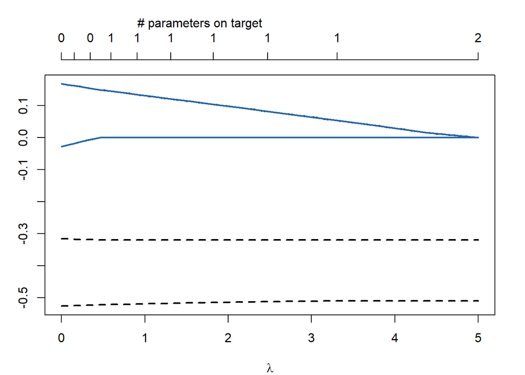

```r
plot(regModel)
```

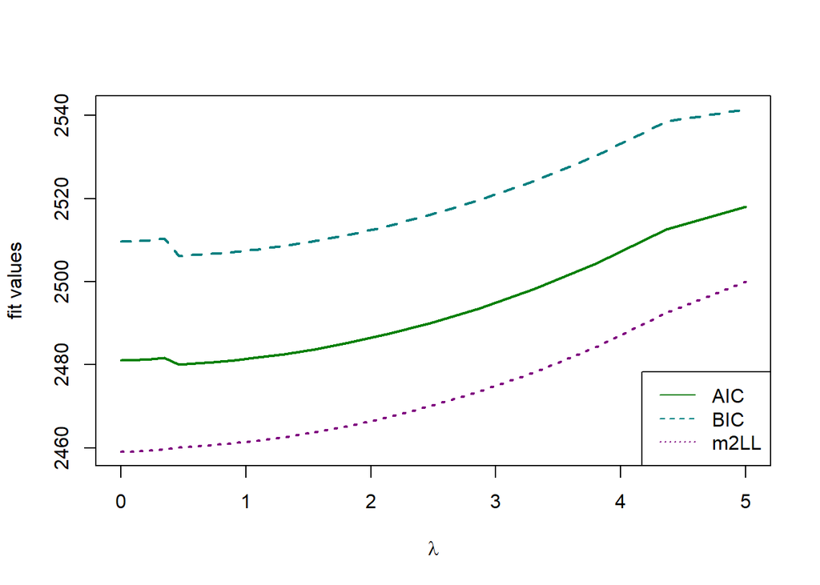

```r
plot(regModel, what = "fit", criterion = c("AIC", "BIC", "m2LL"))
```